# Lending Club - Identifying Factors that Influence Customers Defaulting on Loans

```r
library('readxl')
library('tidyverse')
library('janitor')
library('GGally')
library('fastDummies')
library('ggfortify')
library('mosaic')
library('mosaicData')
library('modelr')
library('readxl')
library('broom')
library("wesanderson")
library("RColorBrewer")
```

```r
library(readr)
lending_club_loans <- read_csv("C:/Users/44792/OneDrive/Desktop/Codeclan 2022/final_project_loan_default_predictor/data/lending_club_loans.csv")
View(lending_club_loans)
```

# Background

#### Lending Club (LC) was established in 2007 and there are now over 4 million members. It is a peer-to-peer lender (P2P) and the first in the USA to register its offering as securities with SEC (Securities and Exchange Commission). LC intersects technology and finance and with this approach there is the possibility of progressing a more stream-lined business model with an on-line offering and no physical facilities. In addition they use machine learning to develop a risk management model that can eliminate lending bias and also focus on the most profitable customer base.

#### LC also has two distinct customer bases. The loan customer and then the lenders. They are a signifiant network of people providing the micro-loans and as a consequence of this model it is essential that business information is transparent enough for lenders to make informed decision about the percentage of defaults but also the rate of return for their funds.

#### This data and the subsequent model is a good example of how DDD (Data Driven Decisions) can be used to ensure there is a more transparent approach to accessing personal finance and also investing in new ways.

#### The data set is from Kaggle and is collected from 2007-2018 accepted applications.

# Ethical consideration in the development of Machine Learning Models

#### When gathering personal data consumer data protection legislation needs to be considered, respected and the legislation followed.

#### Secondly, when considering the use of machine learning it is important to be transparent with customer and investors about the use of machine learning during the decision-making process. As noted in the 2021 annual reports from LC their marketing materials are clear that the company use over 150million cells of data to support the use of artificial intelligence-driven credit decisions and machine learning models are being used across the customer lifecycle to potentially expand access to credit.

#### Diversity and inclusion in the development of a model is also important as bias can be introduced if the machine learning models are limited by the data that it gets to train on. Developing a team with a wide range of experience and from a diverse range of backgrounds is important to progress this. I would go so far to say that it is particularly important to engage people with direct experience of some of the challenges of restricted access to credit due to personal or work situations.

#### I would recommend that further work be done on some of the new test models “What If” by Google so that the models can be challenged using a number of other data inputs.

# Data Preparation and Cleaning

```r
view(lending_club_loans)
lending_club_loans <- clean_names(lending_club_loans)
```

```r
lendingverification <- lending_club_loans%>%
select(verification_status, loan_status)
view(lendingverification)
glimpse(lendingverification)
```

```
Rows: 42,538
Columns: 2
$ verification_status <chr> "Verified", "Source Verified", "Not Verified", "Source…
$ loan_status         <chr> "Fully Paid", "Charged Off", "Fully Paid", "Fully Paid…
```

```r
lendingverification%>%
  count(loan_status, verification_status)
```

| loan_status | verification_status | n |
| --- | --- | --- |
| Charged Off | Not Verified | 2144 |
| Charged Off | Source Verified | 1444 |
| Charged Off | Verified | 2065 |
| Current | Not Verified | 79 |
| Current | Source Verified | 139 |
| Current | Verified | 295 |
| Default | Source Verified | 1 |
| Does not meet the credit policy. Status:Charged Off | Not Verified | 511 |
| Does not meet the credit policy. Status:Charged Off | Source Verified | 82 |
| Does not meet the credit policy. Status:Charged Off | Verified | 168 |

[output cut: 15 more lines]

```r
NA
```

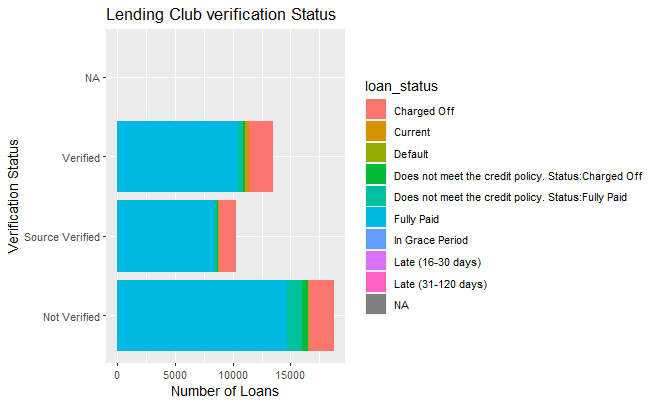

```r
ggplot(lendingverification)+
  geom_bar(aes(x = verification_status, fill = loan_status))+
  coord_flip()+
labs( x= "Verification Status",
        y= "Number of Loans",
        title = "Lending Club verification Status")
```

```r
loans1 <- lending_club_loans %>%
  select(loan_amnt,term,int_rate,sub_grade,home_ownership,annual_inc,purpose, loan_status,emp_length, dti)
```

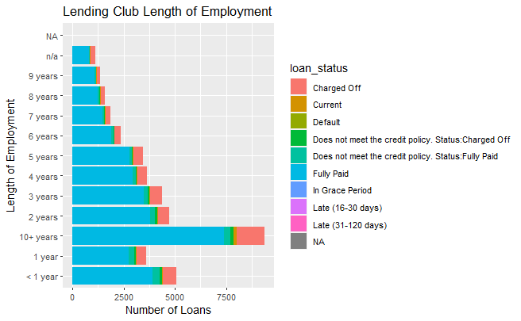

```r
ggplot(loans1)+
  geom_bar(aes(x = emp_length, fill = loan_status))+
  coord_flip()+
labs( x= "Length of Employment",
        y= "Number of Loans",
        title = "Lending Club Length of Employment")
```

# View the structure of the data

```r
glimpse(loans1)
```

```
Rows: 42,538
Columns: 10
$ loan_amnt      <dbl> 5000, 2500, 2400, 10000, 3000, 5000, 7000, 3000, 5600, 5375…
$ term           <chr> "36 months", "60 months", "36 months", "36 months", "60 mon…
$ int_rate       <chr> "10.65%", "15.27%", "15.96%", "13.49%", "12.69%", "7.90%", …
$ sub_grade      <chr> "B2", "C4", "C5", "C1", "B5", "A4", "C5", "E1", "F2", "B5",…
$ home_ownership <chr> "RENT", "RENT", "RENT", "RENT", "RENT", "RENT", "RENT", "RE…
$ annual_inc     <dbl> 24000.00, 30000.00, 12252.00, 49200.00, 80000.00, 36000.00,…
$ purpose        <chr> "credit_card", "car", "small_business", "other", "other", "…
$ loan_status    <chr> "Fully Paid", "Charged Off", "Fully Paid", "Fully Paid", "C…
$ emp_length     <chr> "10+ years", "< 1 year", "10+ years", "10+ years", "1 year"…
$ dti            <dbl> 27.65, 1.00, 8.72, 20.00, 17.94, 11.20, 23.51, 5.35, 5.55, …
```

```r
str(loans1)
```

```
tibble [42,538 × 10] (S3: tbl_df/tbl/data.frame)
 $ loan_amnt     : num [1:42538] 5000 2500 2400 10000 3000 ...
 $ term          : chr [1:42538] "36 months" "60 months" "36 months" "36 months" ...
 $ int_rate      : chr [1:42538] "10.65%" "15.27%" "15.96%" "13.49%" ...
 $ sub_grade     : chr [1:42538] "B2" "C4" "C5" "C1" ...
 $ home_ownership: chr [1:42538] "RENT" "RENT" "RENT" "RENT" ...
 $ annual_inc    : num [1:42538] 24000 30000 12252 49200 80000 ...
 $ purpose       : chr [1:42538] "credit_card" "car" "small_business" "other" ...
 $ loan_status   : chr [1:42538] "Fully Paid" "Charged Off" "Fully Paid" "Fully Paid" ...
 $ emp_length    : chr [1:42538] "10+ years" "< 1 year" "10+ years" "10+ years" ...
 $ dti           : num [1:42538] 27.65 1 8.72 20 17.94 ...
```

```r
summary(loans1)
```

```
   loan_amnt         term             int_rate          sub_grade
 Min.   :  500   Length:42538       Length:42538       Length:42538
 1st Qu.: 5200   Class :character   Class :character   Class :character
 Median : 9700   Mode  :character   Mode  :character   Mode  :character
 Mean   :11090
 3rd Qu.:15000
 Max.   :35000
 NA's   :3
 home_ownership       annual_inc        purpose          loan_status
 Length:42538       Min.   :   1896   Length:42538       Length:42538
 Class :character   1st Qu.:  40000   Class :character   Class :character
 Mode  :character   Median :  59000   Mode  :character   Mode  :character
                    Mean   :  69137
                    3rd Qu.:  82500
                    Max.   :6000000
                    NA's   :7
  emp_length             dti
 Length:42538       Min.   : 0.00
 Class :character   1st Qu.: 8.20
 Mode  :character   Median :13.47
                    Mean   :13.37
                    3rd Qu.:18.68
                    Max.   :29.99
                    NA's   :3
```

```r
loans2 <- loans1 %>%
  filter(!is.na(loan_amnt))
loans2
```

| loan_amnt | term | int_rate | sub_grade | home_ownership | annual_inc | purpose | loan_status | emp_length | dti |
| --- | --- | --- | --- | --- | --- | --- | --- | --- | --- |
| 5000 | 36 months | 10.65% | B2 | RENT | 24000.00 | credit_card | Fully Paid | 10+ years | 27.65 |
| 2500 | 60 months | 15.27% | C4 | RENT | 30000.00 | car | Charged Off | < 1 year | 1.00 |
| 2400 | 36 months | 15.96% | C5 | RENT | 12252.00 | small_business | Fully Paid | 10+ years | 8.72 |
| 10000 | 36 months | 13.49% | C1 | RENT | 49200.00 | other | Fully Paid | 10+ years | 20.00 |
| 3000 | 60 months | 12.69% | B5 | RENT | 80000.00 | other | Current | 1 year | 17.94 |
| 5000 | 36 months | 7.90% | A4 | RENT | 36000.00 | wedding | Fully Paid | 3 years | 11.20 |
| 7000 | 60 months | 15.96% | C5 | RENT | 47004.00 | debt_consolidation | Fully Paid | 8 years | 23.51 |
| 3000 | 36 months | 18.64% | E1 | RENT | 48000.00 | car | Fully Paid | 9 years | 5.35 |
| 5600 | 60 months | 21.28% | F2 | OWN | 40000.00 | small_business | Charged Off | 4 years | 5.55 |
| 5375 | 60 months | 12.69% | B5 | RENT | 15000.00 | other | Charged Off | < 1 year | 18.08 |

[output cut: 990 more lines]

```r
loans3 <- loans2 %>%
  filter(!is.na(annual_inc))
```

```r
summary(as.factor(loans2$term))
```

```
36 months 60 months
    31534     11001
```

```r
summary(as.factor(loans2$sub_grade))
```

```
  A1   A2   A3   A4   A5   B1   B2   B3   B4   B5   C1   C2   C3   C4   C5   D1
1142 1520 1823 2905 2793 1882 2113 2997 2590 2807 2264 2157 1658 1370 1291 1053
  D2   D3   D4   D5   E1   E2   E3   E4   E5   F1   F2   F3   F4   F5   G1   G2
1485 1322 1140 1016  884  791  668  552  499  392  308  236  211  154  141  107
  G3   G4   G5
  79   99   86
```

```r
summary(as.factor(loans2$dti))
```

```
      0      12      10      18    19.2    13.2    13.5    16.8   12.48   14.29
    206      54      46      46      45      43      41      41      40      38
     15     4.8       6    20.4     8.4    15.6   17.04    21.6    9.17     9.6
     38      37      37      36      35      35      35      35      34      34
   10.8    12.5   12.86   14.44    6.76   10.64    11.5    17.4    8.88   10.03
     34      34      34      34      33      33      33      33      32      32
  13.75    14.4   14.76   15.38   15.63     7.8       9   12.62   12.69   13.28
     32      32      32      32      32      31      31      31      31      31
  14.97   15.31   16.32   18.72      20   23.52   10.16   10.43   13.51   13.68
     31      31      31      31      31      31      30      30      30      30
  15.36   16.77   19.63    9.48   11.04   11.22   12.27   12.54   12.96    13.1
     30      30      30      29      29      29      29      29      29      29
  14.36   14.74   15.44   15.55   15.77   15.84    16.2   16.36    16.4   16.56
     29      29      29      29      29      29      29      29      29      29
   19.9   20.69   22.43     6.4    6.65       7     8.8    9.66   10.05    10.2
     29      29      29      28      28      28      28      28      28      28
  10.68   10.77   11.35   11.42   12.74   13.65   13.71    13.9      14   14.08
     28      28      28      28      28      28      28      28      28      28
  14.35    14.6   14.73   15.14    15.2   15.53   15.86   16.95   17.16 (Other)
     28      28      28      28      28      28      28      28      28   39228
```

```r
summary(as.factor(loans2$purpose))
```

```
               car        credit_card debt_consolidation        educational
              1615               5477              19776                422
  home_improvement              house     major_purchase            medical
              3199                426               2311                753
            moving              other   renewable_energy     small_business
               629               4425                106               1992
          vacation            wedding
               400               1004
```

```r
summary(as.factor(loans2$loan_status))
```

```
                                        Charged Off
                                               5653
                                            Current
                                                513
                                            Default
                                                  1
Does not meet the credit policy. Status:Charged Off
                                                761
 Does not meet the credit policy. Status:Fully Paid
                                               1988
                                         Fully Paid
                                              33586
                                    In Grace Period
                                                 16
                                  Late (16-30 days)
                                                  5
                                 Late (31-120 days)
                                                 12
```

```r
glimpse(loans3)
```

```
Rows: 42,531
Columns: 10
$ loan_amnt      <dbl> 5000, 2500, 2400, 10000, 3000, 5000, 7000, 3000, 5600, 5375…
$ term           <chr> "36 months", "60 months", "36 months", "36 months", "60 mon…
$ int_rate       <chr> "10.65%", "15.27%", "15.96%", "13.49%", "12.69%", "7.90%", …
$ sub_grade      <chr> "B2", "C4", "C5", "C1", "B5", "A4", "C5", "E1", "F2", "B5",…
$ home_ownership <chr> "RENT", "RENT", "RENT", "RENT", "RENT", "RENT", "RENT", "RE…
$ annual_inc     <dbl> 24000.00, 30000.00, 12252.00, 49200.00, 80000.00, 36000.00,…
$ purpose        <chr> "credit_card", "car", "small_business", "other", "other", "…
$ loan_status    <chr> "Fully Paid", "Charged Off", "Fully Paid", "Fully Paid", "C…
$ emp_length     <chr> "10+ years", "< 1 year", "10+ years", "10+ years", "1 year"…
$ dti            <dbl> 27.65, 1.00, 8.72, 20.00, 17.94, 11.20, 23.51, 5.35, 5.55, …
```

#Further cleaning of the data here at this point to drop the other loan status information.

```r
loansdropped <-loans3 %>%
  filter(loan_status %in% c("Charged Off","Fully Paid"
                    ))
loansdropped %>%
  count(loan_status)
```

| loan_status | n |
| --- | --- |
| Charged Off | 5653 |
| Fully Paid | 33586 |

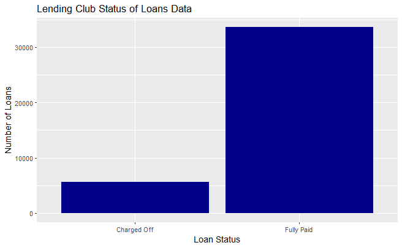

```r
  ggplot(loansdropped) +
  aes(x = emp_length, fill = loan_status)+
  geom_bar(aes(x= loan_status), fill = "dark blue")+
labs( x= "Loan Status",
        y= "Number of Loans",
        title = "Lending Club Status of Loans Data")
```

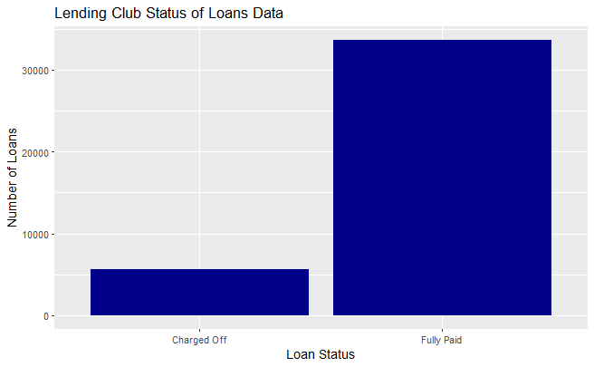

```r
ggplot(loansdropped) +
  aes(x = term, fill = loan_status)+
  geom_bar(aes(x= loan_status), fill = "dark blue")+
labs( x= "Loan Status",
        y= "Number of Loans",
        title = "Lending Club Status of Loans Data")
```

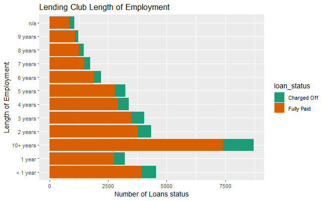

```r
ggplot(loansdropped)+
  aes(x = emp_length, fill = loan_status)+
     geom_bar()+
    scale_fill_brewer(palette = "Dark2")+
  coord_flip()+
labs( x= "Length of Employment",
        y= "Number of Loans status",
        title = "Lending Club Length of Employment")
```

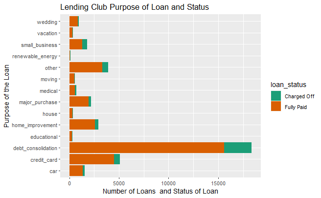

```r
ggplot(loansdropped)+
  aes(x = purpose, fill = loan_status)+
     geom_bar()+
    scale_fill_brewer(palette = "Dark2")+
  coord_flip()+
labs( x= "Purpose of the Loan",
        y= "Number of Loans  and Status of Loan",
        title = "Lending Club Purpose of Loan and Status")
```

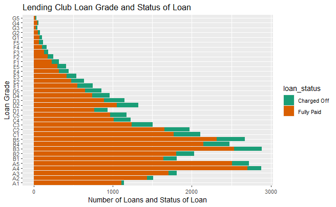

```r
ggplot(loansdropped)+
  aes(x = sub_grade, fill = loan_status)+
     geom_bar()+
    scale_fill_brewer(palette = "Dark2")+
  coord_flip()+
labs( x= "Loan Grade",
        y= "Number of Loans and Status of Loan",
        title = "Lending Club Loan Grade and Status of Loan")
```

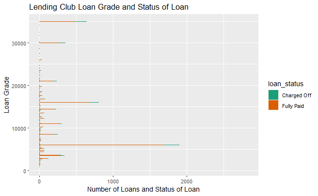

```r
ggplot(loansdropped)+
  aes(x = loan_amnt, fill = loan_status)+
     geom_bar()+
    scale_fill_brewer(palette = "Dark2")+
  coord_flip()+
labs( x= "Loan Grade",
        y= "Number of Loans and Status of Loan",
        title = "Lending Club Loan Grade and Status of Loan")
```

# Key Take Aways

### Total of 42,531 individual loan accounts with 5,653 charged off (meaning that the lender has written off the debt and the account is closed) and 33,586 fully paid off loans.

#### Majority of the loans are for 36 months (74%) and (26%) and for 60 months.

#### The LC internal credit rating ranges from A to G with 5 subcategories (a total of 35 credit ratings). A1 being the least likely to default and G5 the catergory with the highest risk profile. From the data there is an uptick in the defaults at the D3 point onwards until we reach G5.

#### Debt consolidation (19,776 loans) 46% of loans followed by paying off credit card debt (5,477) 13% and then other (4425) 10% are the top three purposes of the loan request. It should be noted that this is self reported and caution should be exercised when considering the validity of this information.

#### While debt consolidation could arise from various other sources, such as auto or home equity lines, loans from these sources are secured and, hence, considerably different than unsecured credit like LC

# Exploriarity analysis

#### Visual and explore the characteristics of the defaults loans only to uderstand more about the type of loan that is written off.

```r
default1 <-loansdropped %>%
  filter(loan_status == "Charged Off")
default1
```

| loan_amnt | term | int_rate | sub_grade | home_ownership | annual_inc | purpose | loan_status | emp_length | dti |
| --- | --- | --- | --- | --- | --- | --- | --- | --- | --- |
| 2500 | 60 months | 15.27% | C4 | RENT | 30000.00 | car | Charged Off | < 1 year | 1.00 |
| 5600 | 60 months | 21.28% | F2 | OWN | 40000.00 | small_business | Charged Off | 4 years | 5.55 |
| 5375 | 60 months | 12.69% | B5 | RENT | 15000.00 | other | Charged Off | < 1 year | 18.08 |
| 9000 | 36 months | 13.49% | C1 | RENT | 30000.00 | debt_consolidation | Charged Off | < 1 year | 10.08 |
| 10000 | 36 months | 10.65% | B2 | RENT | 100000.00 | other | Charged Off | 3 years | 7.06 |
| 21000 | 36 months | 12.42% | B4 | RENT | 105000.00 | debt_consolidation | Charged Off | 10+ years | 13.22 |
| 6000 | 36 months | 11.71% | B3 | RENT | 76000.00 | major_purchase | Charged Off | 1 year | 2.40 |
| 15000 | 36 months | 14.27% | C2 | RENT | 60000.00 | debt_consolidation | Charged Off | 9 years | 15.22 |
| 5000 | 60 months | 16.77% | D2 | RENT | 50004.00 | other | Charged Off | 2 years | 13.97 |
| 5000 | 36 months | 8.90% | A5 | MORTGAGE | 100000.00 | debt_consolidation | Charged Off | 10+ years | 16.33 |

[output cut: 990 more lines]

```r
glimpse(default1)
```

```
Rows: 5,653
Columns: 10
$ loan_amnt      <dbl> 2500, 5600, 5375, 9000, 10000, 21000, 6000, 15000, 5000, 50…
$ term           <chr> "60 months", "60 months", "60 months", "36 months", "36 mon…
$ int_rate       <chr> "15.27%", "21.28%", "12.69%", "13.49%", "10.65%", "12.42%",…
$ sub_grade      <chr> "C4", "F2", "B5", "C1", "B2", "B4", "B3", "C2", "D2", "A5",…
$ home_ownership <chr> "RENT", "OWN", "RENT", "RENT", "RENT", "RENT", "RENT", "REN…
$ annual_inc     <dbl> 30000, 40000, 15000, 30000, 100000, 105000, 76000, 60000, 5…
$ purpose        <chr> "car", "small_business", "other", "debt_consolidation", "ot…
$ loan_status    <chr> "Charged Off", "Charged Off", "Charged Off", "Charged Off",…
$ emp_length     <chr> "< 1 year", "4 years", "< 1 year", "< 1 year", "3 years", "…
$ dti            <dbl> 1.00, 5.55, 18.08, 10.08, 7.06, 13.22, 2.40, 15.22, 13.97, …
```

```r
summary(default1)
```

[output not shown]

```r
default1 %>%
  group_by(term, term_count = n())
```

```r
default1%>%
  count(loan_status)
```

```r
glimpse(default1)
```

```r
default1%>%
  select(term)%>%
count()
```

| n |
| --- |
| 5653 |

```r
defaulthome <-default1 %>%
  group_by(home_ownership) %>%
  summarise(n = n ())
view(defaulthome)
summarise(defaulthome)
```

```r
default_arranged <- default1 %>%
  select(loan_amnt, term)%>%
  arrange(desc(loan_amnt))
```

```r
summary(default_arranged)
```

```
   loan_amnt         term
 Min.   :  900   Length:5653
 1st Qu.: 5600   Class :character
 Median :10000   Mode  :character
 Mean   :12134
 3rd Qu.:16750
 Max.   :35000
```

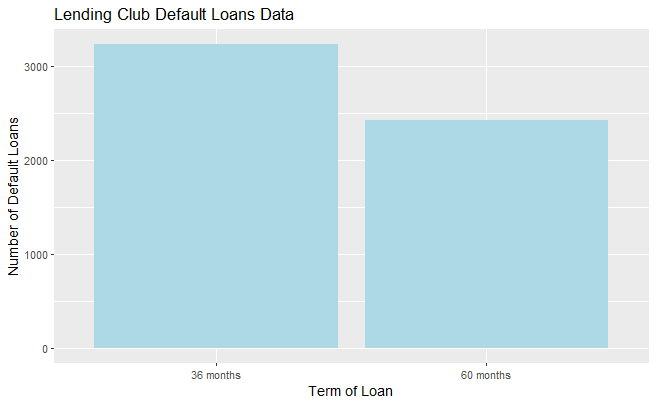

```r
ggplot(default1) +
  geom_bar(aes(x= term), fill = "light blue")+
labs( x= "Term of Loan",
        y= "Number of Default Loans",
        title = "Lending Club Default Loans Data")
```

#### For the purpose of this work the loan term could be considered a factor in the probability of a customer defaulting.

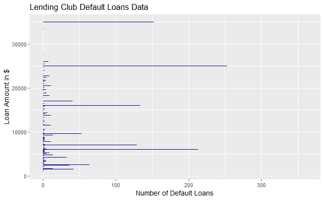

```r
ggplot(default1) +
  geom_bar(aes(x= loan_amnt), fill = "dark blue")+
  coord_flip()+
labs( x= "Loan Amount in $",
        y= "Number of Default Loans",
        title = "Lending Club Default Loans Data")
```

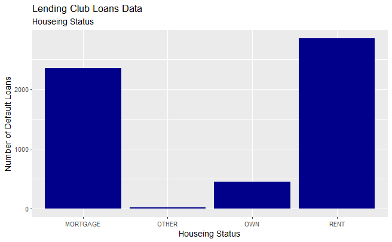

```r
ggplot(default1) +
  geom_bar(aes(x=home_ownership), fill = "dark blue")+
   labs( x= "Houseing Status",
        y= "Number of Default Loans",
        title = "Lending Club Loans Data",
        subtitle = "Houseing Status")
```

#### An applicants housing status can also be considerd a factor in default loans. There is a a higher percentage of renters - unsurprising and also might be considered a higher risk when lending as a credit check cannot be secured from other traditional lender. Furthermore those with a mortage may be in a position to get a loan that is secured against their property. Housing status could be considered a factor in the probability of a customer defaulting.

#### There is a slight increase in the number of people defaulting who are renters with 50% renting and 41% having a mortage. For the purpose of the model home status could be consider a factor in the probabilty of a customer defaulting.

```r
default_dti <-default1 %>%
  select(dti, term)%>%
  arrange(desc(dti))
```

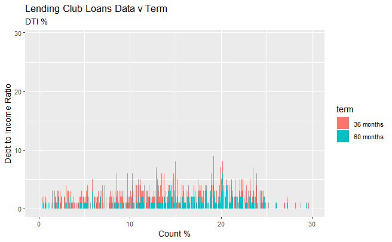

```r
ggplot(default_dti) +
  geom_bar(aes (x = dti, fill = term), stat = "count")+
  labs( x= "Count %",
        y= "Debt to Income Ratio",
        title = "Lending Club Loans Data v Term",
        subtitle = "DTI %")
```

```r
NA
```

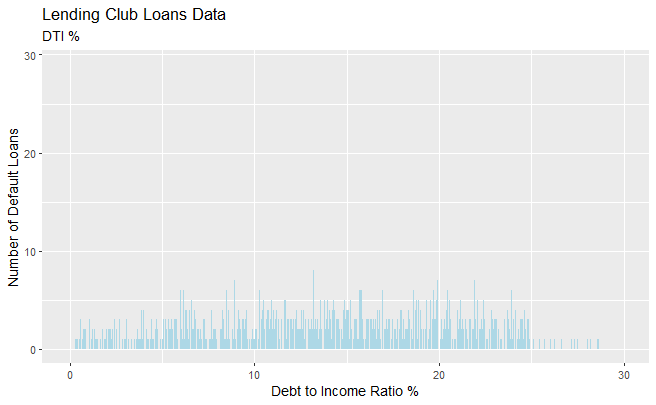

```r
ggplot(default1) +
  geom_bar(aes(x=dti), fill = "light blue")+
   labs( x= "Debt to Income Ratio %",
        y= "Number of Default Loans",
        title = "Lending Club Loans Data",
        subtitle = "DTI %")
```

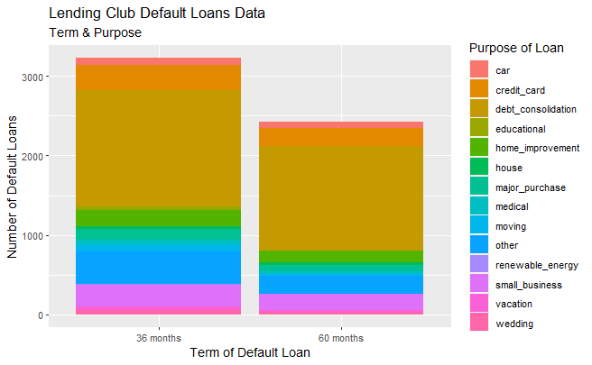

```r
ggplot(default1) +
  geom_bar(aes(x= term, fill = purpose))+
  labs( x= "Term of Default Loan",
        y= "Number of Default Loans",
        title = "Lending Club Default Loans Data",
        subtitle = "Term & Purpose",
        fill = "Purpose of Loan")
```

#### Limiting exposure to the loans being used for this purpose may be a consideration in the future or offering a higher interest rate to mitiage the risk.

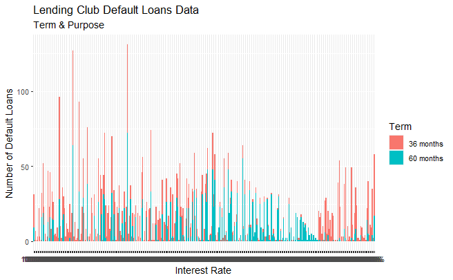

```r
ggplot(default1) +
  geom_bar(aes(x= int_rate, fill = term))+
  labs( x= "Interest Rate",
        y= "Number of Default Loans",
        title = "Lending Club Default Loans Data",
        subtitle = "Term & Purpose",
        fill = "Term")
```

```r
ggplot(default1) +
  geom_bar(aes(x= term, fill = annual_inc))+
  labs( x= "Term of Default Loan",
        y= "Number of Default Loans",
        title = "Lending Club Default Loans Data",
        subtitle = "Term & Purpose",
        fill = "Purpose of Loan")
```

[output not shown]

#loan status needs to be turned into a numerical column 0 or 1 for purpose of building a predictive model.

# Prediction of Loan Defaults

#### Our ultimate goal is the prediction of loan defaults from a given set of observations by selecting explanatory (independent) variables (also called feature in machine learning) that result in an acceptable model performance as quantified by a pre-defined measure. This goal will also impact our exploratory data analysis.

```r
loansmodelling <-loansdropped %>%
  mutate(loan_status = recode(loan_status,"Fully Paid" = FALSE, "Charged Off" = TRUE))
loansmodelling
```

| loan_amnt | term | int_rate | sub_grade | home_ownership | annual_inc | purpose | loan_status | emp_length | dti |
| --- | --- | --- | --- | --- | --- | --- | --- | --- | --- |
| 5000 | 36 months | 10.65% | B2 | RENT | 24000.00 | credit_card | FALSE | 10+ years | 27.65 |
| 2500 | 60 months | 15.27% | C4 | RENT | 30000.00 | car | TRUE | < 1 year | 1.00 |
| 2400 | 36 months | 15.96% | C5 | RENT | 12252.00 | small_business | FALSE | 10+ years | 8.72 |
| 10000 | 36 months | 13.49% | C1 | RENT | 49200.00 | other | FALSE | 10+ years | 20.00 |
| 5000 | 36 months | 7.90% | A4 | RENT | 36000.00 | wedding | FALSE | 3 years | 11.20 |
| 7000 | 60 months | 15.96% | C5 | RENT | 47004.00 | debt_consolidation | FALSE | 8 years | 23.51 |
| 3000 | 36 months | 18.64% | E1 | RENT | 48000.00 | car | FALSE | 9 years | 5.35 |
| 5600 | 60 months | 21.28% | F2 | OWN | 40000.00 | small_business | TRUE | 4 years | 5.55 |
| 5375 | 60 months | 12.69% | B5 | RENT | 15000.00 | other | TRUE | < 1 year | 18.08 |
| 6500 | 60 months | 14.65% | C3 | OWN | 72000.00 | debt_consolidation | FALSE | 5 years | 16.12 |

[output cut: 990 more lines]

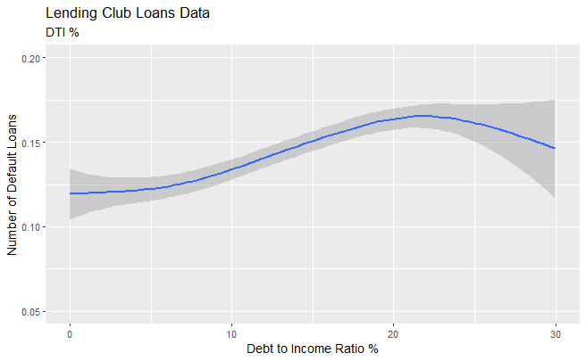

```r
ggplot(loansmodelling,
       aes(x=dti, y = as.integer (loan_status))) +
  geom_point(fill = "light blue")+
  geom_smooth()+
  coord_cartesian(ylim = c(0.05, 0.2))+
   labs( x= "Debt to Income Ratio %",
        y= "Number of Default Loans",
        title = "Lending Club Loans Data",
        subtitle = "DTI %")
```

```r
glimpse(loansmodelling)
```

```r
head(loansmodelling, 15)
```

| loan_amnt | term | int_rate | sub_grade | home_ownership | annual_inc | purpose | loan_status | emp_length | dti |
| --- | --- | --- | --- | --- | --- | --- | --- | --- | --- |
| 5000 | 36 months | 10.65% | B2 | RENT | 24000 | credit_card | FALSE | 10+ years | 27.65 |
| 2500 | 60 months | 15.27% | C4 | RENT | 30000 | car | TRUE | < 1 year | 1.00 |
| 2400 | 36 months | 15.96% | C5 | RENT | 12252 | small_business | FALSE | 10+ years | 8.72 |
| 10000 | 36 months | 13.49% | C1 | RENT | 49200 | other | FALSE | 10+ years | 20.00 |
| 5000 | 36 months | 7.90% | A4 | RENT | 36000 | wedding | FALSE | 3 years | 11.20 |
| 7000 | 60 months | 15.96% | C5 | RENT | 47004 | debt_consolidation | FALSE | 8 years | 23.51 |
| 3000 | 36 months | 18.64% | E1 | RENT | 48000 | car | FALSE | 9 years | 5.35 |
| 5600 | 60 months | 21.28% | F2 | OWN | 40000 | small_business | TRUE | 4 years | 5.55 |
| 5375 | 60 months | 12.69% | B5 | RENT | 15000 | other | TRUE | < 1 year | 18.08 |
| 6500 | 60 months | 14.65% | C3 | OWN | 72000 | debt_consolidation | FALSE | 5 years | 16.12 |

[output cut: 5 more lines]

# Machine Model ~ 1 Logistic Regression

#### My ultimate goal is the prediction of loan defaults from a given set of observations by selecting explanatory (independent) variables (also called features in machine learning) that result in an acceptable model performance. This goal will also impact our exploratory data analysis.

#### the data has been split into two sets identifying loan amount, term and home ownership against the loan status. The final set is annula income, the purpose of the loan and dti (debt to income ratio)

#### GGpairs is then used to see the predictive relationships with the variables.

```r
loans_split1 <- loansmodelling %>%
  select(loan_status, loan_amnt,term,home_ownership)
```

```r
loans_split2 <- loansmodelling %>%
  select(loan_status, annual_inc, purpose, dti)
```

#Now develop the connection with ggpairs

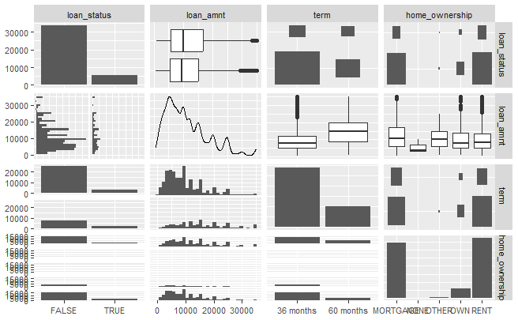

```r
library(GGally)
ggpairs( loans_split1)
```

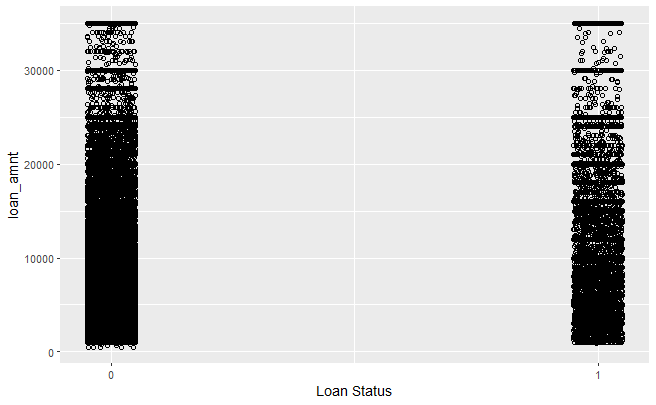

```r
score_plot1 <- ggplot(loans_split1) +
  geom_jitter(aes(y = loan_amnt, x = as.integer(loan_status)), shape = 1,
              position = position_jitter(width = 0.05)) +
  xlab("Loan Status") + scale_x_continuous(breaks=seq(0, 1,1))

score_plot1
```

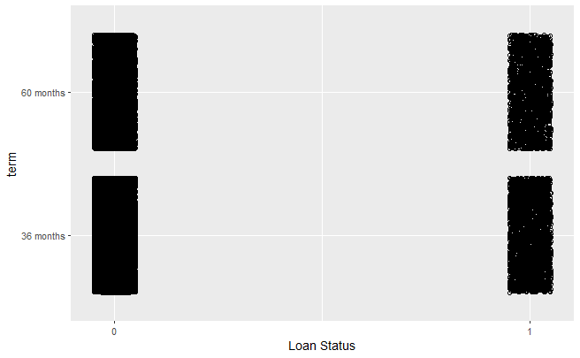

```r
score_plot2 <- ggplot(loans_split1) +
  geom_jitter(aes(y = term, x = as.integer(loan_status)), shape = 1,
              position = position_jitter(width = 0.05)) +
  xlab("Loan Status") + scale_x_continuous(breaks=seq(0, 1,1))

score_plot2
```

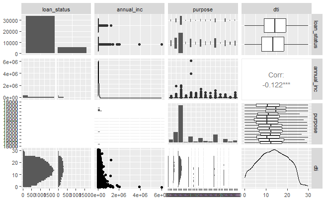

```r
library(GGally)
ggpairs(loans_split2)
```

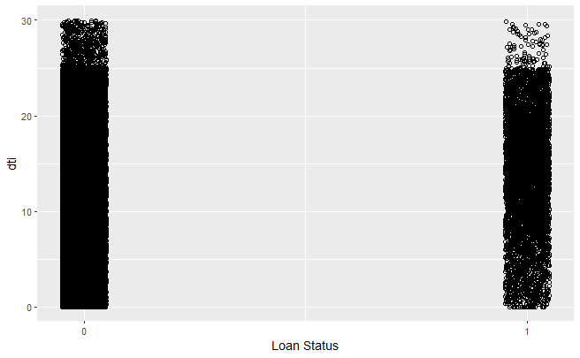

```r
score_plot3 <- ggplot(loans_split2) +
  geom_jitter(aes(y = dti, x = as.integer(loan_status)), shape = 1,
              position = position_jitter(width = 0.05)) +
  xlab("Loan Status") + scale_x_continuous(breaks=seq(0, 1,1))

score_plot3
```

```r
loan_data_logreg_model <- glm(loan_status ~ dti+ loan_amnt+ term +log(annual_inc), data = loansmodelling, family = binomial(link = 'logit'))
loan_data_logreg_model
```

```
Call:  glm(formula = loan_status ~ dti + loan_amnt + term + log(annual_inc),
    family = binomial(link = "logit"), data = loansmodelling)

Coefficients:
    (Intercept)              dti        loan_amnt    term60 months
      3.749e+00        8.736e-03        1.889e-05        8.793e-01
log(annual_inc)
     -5.629e-01

Degrees of Freedom: 39238 Total (i.e. Null);  39234 Residual
Null Deviance:      32350
Residual Deviance: 31060    AIC: 31070
```

#### But we need to think carefully about the statistical significance of each predictor. A good first step in this direction is to examine the p-value of each predictor. Probability value

#### A p-value is a statistical measurement used to validate a hypothesis against observed data. I measures the probability of obtaining the observed results, assuming that the null hypothesis is true. The lower the p-value, the greater the statistical significance of the observed difference

```r
tidy_out <- clean_names(tidy(loan_data_logreg_model))
tidy_out
```

| term | estimate | std_error | statistic | p_value |
| --- | --- | --- | --- | --- |
| (Intercept) | 3.749192e+00 | 3.299491e-01 | 11.362941 | 6.395465e-30 |
| dti | 8.736066e-03 | 2.218290e-03 | 3.938198 | 8.209583e-05 |
| loan_amnt | 1.888953e-05 | 2.322115e-06 | 8.134625 | 4.132157e-16 |
| term60 months | 8.792774e-01 | 3.257663e-02 | 26.991050 | 1.882435e-160 |
| log(annual_inc) | -5.629427e-01 | 3.096069e-02 | -18.182501 | 7.102013e-74 |

```r
loan_data_logreg_model2 <- glm(loan_status ~ purpose + home_ownership + term +log(annual_inc), data = loansmodelling, family = binomial(link = 'logit'))
loan_data_logreg_model2
```

```
Call:  glm(formula = loan_status ~ purpose + home_ownership + term +
    log(annual_inc), family = binomial(link = "logit"), data = loansmodelling)

Coefficients:
              (Intercept)         purposecredit_card  purposedebt_consolidation
                  2.11502                    0.28219                    0.56361
       purposeeducational    purposehome_improvement               purposehouse
                  0.81318                    0.37896                    0.63205
    purposemajor_purchase             purposemedical              purposemoving
                  0.14374                    0.62176                    0.65317
             purposeother    purposerenewable_energy      purposesmall_business
                  0.68041                    0.83645                    1.30830
          purposevacation             purposewedding         home_ownershipNONE
                  0.55634                    0.16169                   -8.49210
      home_ownershipOTHER          home_ownershipOWN         home_ownershipRENT
                  0.57051                    0.01763                    0.07849
            term60 months            log(annual_inc)
                  0.99600                   -0.43859

Degrees of Freedom: 39238 Total (i.e. Null);  39219 Residual
Null Deviance:      32350
Residual Deviance: 30810    AIC: 30850
```

```r
tidy_out <- clean_names(tidy(loan_data_logreg_model2))
tidy_out
```

| term | estimate | std_error | statistic | p_value |
| --- | --- | --- | --- | --- |
| (Intercept) | 2.11501808 | 0.32643661 | 6.4791080 | 9.226644e-11 |
| purposecredit_card | 0.28218845 | 0.09683992 | 2.9139683 | 3.568662e-03 |
| purposedebt_consolidation | 0.56361475 | 0.08755947 | 6.4369366 | 1.219088e-10 |
| purposeeducational | 0.81318381 | 0.17227063 | 4.7203857 | 2.353978e-06 |
| purposehome_improvement | 0.37895664 | 0.10344367 | 3.6634108 | 2.488789e-04 |
| purposehouse | 0.63205436 | 0.16788754 | 3.7647484 | 1.667168e-04 |
| purposemajor_purchase | 0.14374299 | 0.11126127 | 1.2919409 | 1.963776e-01 |
| purposemedical | 0.62176493 | 0.13705783 | 4.5365153 | 5.719134e-06 |
| purposemoving | 0.65316687 | 0.14396387 | 4.5370194 | 5.705485e-06 |
| purposeother | 0.68041063 | 0.09591020 | 7.0942471 | 1.300576e-12 |

[output cut: 10 more lines]

# Recommendations

#### The following are some suggestions to consider in relation to how LC might alter their existing approach to lending so that defaults are reduced.

#### Reduce exposure to longer term loans.

#### Reduce exposure to loans graded D1 and beyond.

#### Model three-tier lending term as opposed to a two-tier.

#### Reduce exposure to debt consolidation/credit card loans.

#### Reduce exposure to customers with a DTI of between 22 - 25% and above.

#### Increase verification of loans information prior to approval.

#### Review the gradiant at which the Loan approval, based on risk profile and mitigation of the risk, and further increase the interest rate.